# Session_4-Analysing Data

In this session, we will look at basic functions in R that will help us in running some inferential statistics. These will help us to evaluate the relationship between one (or more) predictor(s) and an outcome. We will start with a basic example. Using the dataframe “cars”.

# 1 Loading packages

```r
## Use the code below to check if you have all required packages installed. If some are not installed already, the code below will install these. If you have all packages installed, then you could load them with the second code.
requiredPackages = c('ggplot2','tidyverse','psycho','lme4','ordinal','lmerTest')
for(p in requiredPackages){
  if(!require(p,character.only = TRUE)) install.packages(p)
  library(p,character.only = TRUE)
}
# library(ggplot2);library(tidyverse);library(psycho);library(lme4);library(ordinal);library(lmerTest)
```

# 2 Starting with a linear model

```r
head(cars)
```

|  | speed | dist |
| --- | --- | --- |
| 1 | 4 | 2 |
| 2 | 4 | 10 |
| 3 | 7 | 4 |
| 4 | 7 | 22 |
| 5 | 8 | 16 |
| 6 | 9 | 10 |

```r
str(cars)
```

```
'data.frame':   50 obs. of  2 variables:
 $ speed: num  4 4 7 7 8 9 10 10 10 11 ...
 $ dist : num  2 10 4 22 16 10 18 26 34 17 ...
```

```r
summary(cars)
```

```
     speed           dist
 Min.   : 4.0   Min.   :  2.00
 1st Qu.:12.0   1st Qu.: 26.00
 Median :15.0   Median : 36.00
 Mean   :15.4   Mean   : 42.98
 3rd Qu.:19.0   3rd Qu.: 56.00
 Max.   :25.0   Max.   :120.00
```

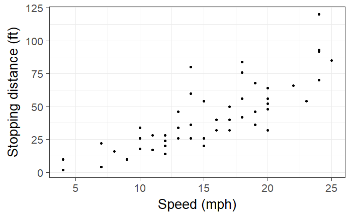

```r
ggplot.cars1 <- ggplot(cars,aes(x=speed,y=dist))+
                geom_point()+theme_bw(base_size = 20)+
                labs(y = "Stopping distance (ft)", x = "Speed (mph)")
ggplot.cars1
```

## 2.1 Basic correlations and plotting the linear relationship

Let us do some basic correlation analysis using base R and package psycho. And let’s visualise this correlation using a linear regression line

```r
cor(cars)
```

```
          speed      dist
speed 1.0000000 0.8068949
dist  0.8068949 1.0000000
```

```r
## correlation using "psycho"
cars %>%
  correlation()
```

```
Pearson Full Correlation (p value correction: holm):
   - speed - dist:   Results of the Pearson correlation showed a significant and strong negative association between speed and dist (r(48) = 0.81, p < .001***).
```

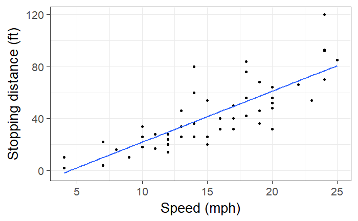

```r
ggplot.cars2 <- ggplot(cars,aes(x=speed,y=dist))+
                geom_point()+theme_bw(base_size = 20)+
                labs(y = "Stopping distance (ft)", x = "Speed (mph)")+
                geom_smooth(method = lm, se=F)
ggplot.cars2
```

## 2.2 Our first statistical model

What about running our first statistical analysis of the data? We will use a Linear regression model. We can visualise the results using “summary”. If you are new to linear models and prefer an ANOVA-style analysis, then use the function “ANOVA” on the linear model. We’ll come back to the linear model later on.

```r
mdl.lm <- lm(dist~speed, data=cars)
mdl.lm#also print(mdl.lm)
```

```
Call:
lm(formula = dist ~ speed, data = cars)

Coefficients:
(Intercept)        speed
    -17.579        3.932
```

```r
summary(mdl.lm)
```

```
Call:
lm(formula = dist ~ speed, data = cars)

Residuals:
    Min      1Q  Median      3Q     Max
-29.069  -9.525  -2.272   9.215  43.201

Coefficients:
            Estimate Std. Error t value Pr(>|t|)
(Intercept) -17.5791     6.7584  -2.601   0.0123 *
speed         3.9324     0.4155   9.464 1.49e-12 ***
---
Signif. codes:  0 ‘***’ 0.001 ‘**’ 0.01 ‘*’ 0.05 ‘.’ 0.1 ‘ ’ 1

Residual standard error: 15.38 on 48 degrees of freedom
Multiple R-squared:  0.6511,    Adjusted R-squared:  0.6438
F-statistic: 89.57 on 1 and 48 DF,  p-value: 1.49e-12
```

```r
anova(mdl.lm)
```

```
Analysis of Variance Table

Response: dist
          Df Sum Sq Mean Sq F value   Pr(>F)
speed      1  21186 21185.5  89.567 1.49e-12 ***
Residuals 48  11354   236.5
---
Signif. codes:  0 ‘***’ 0.001 ‘**’ 0.01 ‘*’ 0.05 ‘.’ 0.1 ‘ ’ 1
```

To interpret the model, we need look at the coefficients. The “Intercept” is -17.5791 and the coefficient for “speed” is 3.9324. This tells us that when “speed” = 0, the “distance” is at -17.5791; with one unit increase in “speed”, the “distance” increases by 3.9324 (ft). There may be some issues with interpretation of this model and we need to center, standardise scores. We are not going to cover this here, but you can center and/or scale with this formula:

1. Center = scale(x, center = TRUE, scale = FALSE)
2. Standardise = scale(x, center = TRUE, scale = TRUE)

### 2.2.1 Dissecting the model

Let us dissect the model. If you use “str”, you will be able to see what is available under our linear model. To access some info from the model

### 2.2.2 “str” and “coef”

```r
str(mdl.lm)
```

```
List of 12
 $ coefficients : Named num [1:2] -17.58 3.93
  ..- attr(*, "names")= chr [1:2] "(Intercept)" "speed"
 $ residuals    : Named num [1:50] 3.85 11.85 -5.95 12.05 2.12 ...
  ..- attr(*, "names")= chr [1:50] "1" "2" "3" "4" ...
 $ effects      : Named num [1:50] -303.914 145.552 -8.115 9.885 0.194 ...
  ..- attr(*, "names")= chr [1:50] "(Intercept)" "speed" "" "" ...
 $ rank         : int 2
 $ fitted.values: Named num [1:50] -1.85 -1.85 9.95 9.95 13.88 ...
  ..- attr(*, "names")= chr [1:50] "1" "2" "3" "4" ...
 $ assign       : int [1:2] 0 1
 $ qr           :List of 5
  ..$ qr   : num [1:50, 1:2] -7.071 0.141 0.141 0.141 0.141 ...
  .. ..- attr(*, "dimnames")=List of 2
  .. .. ..$ : chr [1:50] "1" "2" "3" "4" ...
  .. .. ..$ : chr [1:2] "(Intercept)" "speed"
  .. ..- attr(*, "assign")= int [1:2] 0 1
  ..$ qraux: num [1:2] 1.14 1.27
  ..$ pivot: int [1:2] 1 2
  ..$ tol  : num 1e-07
  ..$ rank : int 2
  ..- attr(*, "class")= chr "qr"
 $ df.residual  : int 48
 $ xlevels      : Named list()
 $ call         : language lm(formula = dist ~ speed, data = cars)
 $ terms        :Classes 'terms', 'formula'  language dist ~ speed
  .. ..- attr(*, "variables")= language list(dist, speed)
  .. ..- attr(*, "factors")= int [1:2, 1] 0 1
  .. .. ..- attr(*, "dimnames")=List of 2
  .. .. .. ..$ : chr [1:2] "dist" "speed"
  .. .. .. ..$ : chr "speed"
  .. ..- attr(*, "term.labels")= chr "speed"
  .. ..- attr(*, "order")= int 1
  .. ..- attr(*, "intercept")= int 1
  .. ..- attr(*, "response")= int 1
  .. ..- attr(*, ".Environment")=<environment: R_GlobalEnv>
  .. ..- attr(*, "predvars")= language list(dist, speed)
  .. ..- attr(*, "dataClasses")= Named chr [1:2] "numeric" "numeric"
  .. .. ..- attr(*, "names")= chr [1:2] "dist" "speed"
 $ model        :'data.frame':  50 obs. of  2 variables:
  ..$ dist : num [1:50] 2 10 4 22 16 10 18 26 34 17 ...
  ..$ speed: num [1:50] 4 4 7 7 8 9 10 10 10 11 ...
  ..- attr(*, "terms")=Classes 'terms', 'formula'  language dist ~ speed
  .. .. ..- attr(*, "variables")= language list(dist, speed)
  .. .. ..- attr(*, "factors")= int [1:2, 1] 0 1
  .. .. .. ..- attr(*, "dimnames")=List of 2
  .. .. .. .. ..$ : chr [1:2] "dist" "speed"
  .. .. .. .. ..$ : chr "speed"
  .. .. ..- attr(*, "term.labels")= chr "speed"
  .. .. ..- attr(*, "order")= int 1
  .. .. ..- attr(*, "intercept")= int 1
  .. .. ..- attr(*, "response")= int 1
  .. .. ..- attr(*, ".Environment")=<environment: R_GlobalEnv>
  .. .. ..- attr(*, "predvars")= language list(dist, speed)
  .. .. ..- attr(*, "dataClasses")= Named chr [1:2] "numeric" "numeric"
  .. .. .. ..- attr(*, "names")= chr [1:2] "dist" "speed"
 - attr(*, "class")= chr "lm"
```

```r
coef(mdl.lm)
```

```
(Intercept)       speed
 -17.579095    3.932409
```

```r
## same as
## mdl.lm$coefficients
```

#### 2.2.2.1 “coef” and “coefficients”

What if I want to obtain the “Intercept”? Or the coefficient for distance? What if I want the full row for distance?

```r
coef(mdl.lm)[1] # same as mdl.lm$coefficients[1]
```

```
(Intercept)
  -17.57909
```

```r
coef(mdl.lm)[2] # same as mdl.lm$coefficients[2]
```

```
   speed
3.932409
```

```r
summary(mdl.lm)$coefficients[2, ] # full row
```

```
    Estimate   Std. Error      t value     Pr(>|t|)
3.932409e+00 4.155128e-01 9.463990e+00 1.489836e-12
```

```r
summary(mdl.lm)$coefficients[2, 4] #for p value
```

```
[1] 1.489836e-12
```

What about residuals (difference between the observed value and the estimated value of the quantity) and fitted values?

```r
residuals(mdl.lm)
```

```
         1          2          3          4          5          6          7
  3.849460  11.849460  -5.947766  12.052234   2.119825  -7.812584  -3.744993
         8          9         10         11         12         13         14
  4.255007  12.255007  -8.677401   2.322599 -15.609810  -9.609810  -5.609810
        15         16         17         18         19         20         21
 -1.609810  -7.542219   0.457781   0.457781  12.457781 -11.474628  -1.474628
        22         23         24         25         26         27         28
 22.525372  42.525372 -21.407036 -15.407036  12.592964 -13.339445  -5.339445
        29         30         31         32         33         34         35
-17.271854  -9.271854   0.728146 -11.204263   2.795737  22.795737  30.795737
        36         37         38         39         40         41         42
-21.136672 -11.136672  10.863328 -29.069080 -13.069080  -9.069080  -5.069080
        43         44         45         46         47         48         49
  2.930920  -2.933898 -18.866307  -6.798715  15.201285  16.201285  43.201285
        50
  4.268876
```

```r
fitted(mdl.lm)
```

```
        1         2         3         4         5         6         7         8
-1.849460 -1.849460  9.947766  9.947766 13.880175 17.812584 21.744993 21.744993
        9        10        11        12        13        14        15        16
21.744993 25.677401 25.677401 29.609810 29.609810 29.609810 29.609810 33.542219
       17        18        19        20        21        22        23        24
33.542219 33.542219 33.542219 37.474628 37.474628 37.474628 37.474628 41.407036
       25        26        27        28        29        30        31        32
41.407036 41.407036 45.339445 45.339445 49.271854 49.271854 49.271854 53.204263
       33        34        35        36        37        38        39        40
53.204263 53.204263 53.204263 57.136672 57.136672 57.136672 61.069080 61.069080
       41        42        43        44        45        46        47        48
61.069080 61.069080 61.069080 68.933898 72.866307 76.798715 76.798715 76.798715
       49        50
76.798715 80.731124
```

#### 2.2.2.2 Goodness of fit?

```r
AIC(mdl.lm) # Akaike's Information Criterion, lower values are better
```

```
[1] 419.1569
```

```r
BIC(mdl.lm) # Bayesian AIC
```

```
[1] 424.8929
```

```r
logLik(mdl.lm)  # log likelihood
```

```
'log Lik.' -206.5784 (df=3)
```

#### 2.2.2.3 Significance testing

Are the above informative? of course not directly. If we want to test for overall significance of model. We run a null model (aka intercept only) and compare models.

```r
mdl.lm.Null <- lm(dist~1, data=cars)
anova(mdl.lm,mdl.lm.Null)
```

```
Analysis of Variance Table

Model 1: dist ~ speed
Model 2: dist ~ 1
  Res.Df   RSS Df Sum of Sq      F   Pr(>F)
1     48 11354
2     49 32539 -1    -21186 89.567 1.49e-12 ***
---
Signif. codes:  0 ‘***’ 0.001 ‘**’ 0.01 ‘*’ 0.05 ‘.’ 0.1 ‘ ’ 1
```

#### 2.2.2.4 Plotting fitted values

Let’s plot our fitted values. Any problems with this?

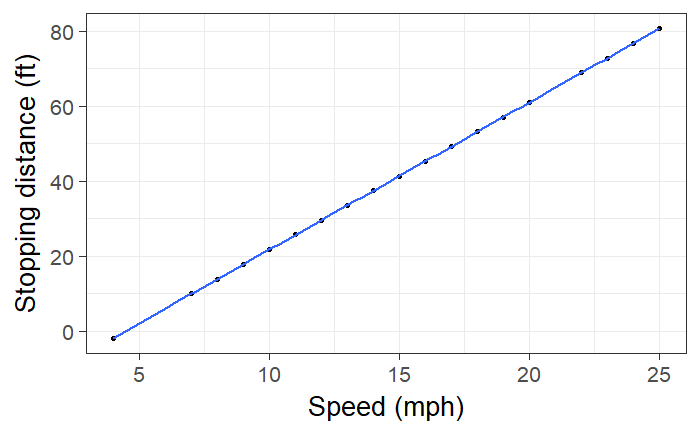

```r
ggplot.cars3 <- ggplot(cars,aes(x=speed,y=predict(mdl.lm)))+
                geom_point()+theme_bw(base_size = 20)+
                labs(y = "Stopping distance (ft)", x = "Speed (mph)")+
                geom_smooth(method = lm, se=F)
ggplot.cars3
```

## 2.3 Some cool correlations

Above, we had two predictors and we checked for correlations. What if we have more predictors and we want to have cool correlation tables and plots? (see here https://www.r-bloggers.com/beautiful-and-powerful-correlation-tables-in-r/amp/)

### 2.3.1 With corrections

```r
cor <- psycho::affective %>%
  correlation()
summary(cor)
```

|  | Age | Life_Satisfaction | Concealing | Adjusting |
| --- | --- | --- | --- | --- |
| Age |  |  |  |  |
| Life_Satisfaction | 0.03 |  |  |  |
| Concealing | -0.05 | -0.06 |  |  |
| Adjusting | 0.03 | 0.36*** | 0.22*** |  |
| Tolerating | 0.03 | 0.15*** | 0.07 | 0.29*** |

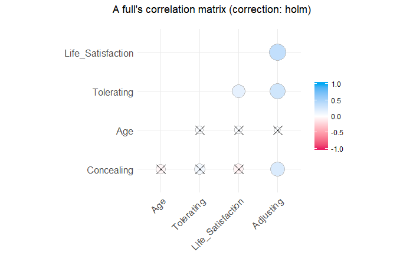

```r
plot(cor)
```

```r
print(cor)
```

```
Pearson Full Correlation (p value correction: holm):
   - Age - Life_Satisfaction:   Results of the Pearson correlation showed a non significant and weak negative association between Age and Life_Satisfaction (r(1249) = 0.030, p > .1).
   - Age - Concealing:   Results of the Pearson correlation showed a non significant and weak positive association between Age and Concealing (r(1249) = -0.050, p > .1).
   - Life_Satisfaction - Concealing:   Results of the Pearson correlation showed a non significant and weak positive association between Life_Satisfaction and Concealing (r(1249) = -0.063, p > .1).
   - Age - Adjusting:   Results of the Pearson correlation showed a non significant and weak negative association between Age and Adjusting (r(1249) = 0.027, p > .1).
   - Life_Satisfaction - Adjusting:   Results of the Pearson correlation showed a significant and moderate negative association between Life_Satisfaction and Adjusting (r(1249) = 0.36, p < .001***).
   - Concealing - Adjusting:   Results of the Pearson correlation showed a significant and weak negative association between Concealing and Adjusting (r(1249) = 0.22, p < .001***).
   - Age - Tolerating:   Results of the Pearson correlation showed a non significant and weak negative association between Age and Tolerating (r(1249) = 0.031, p > .1).
   - Life_Satisfaction - Tolerating:   Results of the Pearson correlation showed a significant and weak negative association between Life_Satisfaction and Tolerating (r(1249) = 0.15, p < .001***).
   - Concealing - Tolerating:   Results of the Pearson correlation showed a non significant and weak negative association between Concealing and Tolerating (r(1249) = 0.074, p = 0.05°).
   - Adjusting - Tolerating:   Results of the Pearson correlation showed a significant and weak negative association between Adjusting and Tolerating (r(1249) = 0.29, p < .001***).
```

### 2.3.2 No corrections

What of we don’t want to use corrections for multiple comparisons?

```r
cor <- psycho::affective %>%
  correlation(adjust="none")
summary(cor)
```

|  | Age | Life_Satisfaction | Concealing | Adjusting |
| --- | --- | --- | --- | --- |
| Age |  |  |  |  |
| Life_Satisfaction | 0.03 |  |  |  |
| Concealing | -0.05 | -0.06* |  |  |
| Adjusting | 0.03 | 0.36*** | 0.22*** |  |
| Tolerating | 0.03 | 0.15*** | 0.07** | 0.29*** |

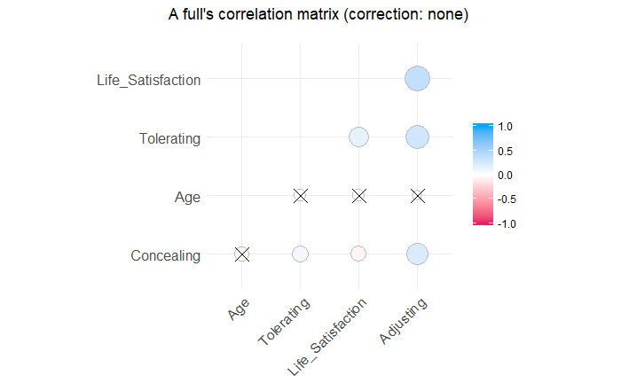

```r
plot(cor)
```

### 2.3.3 Issues with no corrections

Let’s generate a dataframe with 11 predictors and 1000 rows each. Because these are simulated data, there is no underlying correlation between these.

```r
df_with_11_vars <- data.frame(replicate(11, rnorm(1000)))
cor2 <- correlation(df_with_11_vars, adjust="none")
summary(cor2)
```

|  | X1 | X2 | X3 | X4 | X5 | X6 | X7 | X8 | X9 | X10 | X11 | Local_Air_Density | Reincarnation_Cycle | Communism_Level | Alien_Mothership_Distance | Schopenhauers_Optimism |
| --- | --- | --- | --- | --- | --- | --- | --- | --- | --- | --- | --- | --- | --- | --- | --- | --- |
| X1 |  |  |  |  |  |  |  |  |  |  |  |  |  |  |  |  |
| X2 | 0.02 |  |  |  |  |  |  |  |  |  |  |  |  |  |  |  |
| X3 | -0.09** | -0.01 |  |  |  |  |  |  |  |  |  |  |  |  |  |  |
| X4 | 0.05 | 0.02 | 0.01 |  |  |  |  |  |  |  |  |  |  |  |  |  |
| X5 | 0.02 | -0.02 | 0.01 | 0.02 |  |  |  |  |  |  |  |  |  |  |  |  |
| X6 | -0.02 | 0.05 | -0.05 | -0.02 | 0.03 |  |  |  |  |  |  |  |  |  |  |  |
| X7 | -0.04 | 0.04 | 0.00 | 0.00 | 0.01 | -0.03 |  |  |  |  |  |  |  |  |  |  |
| X8 | 0.02 | -0.03 | 0.03 | 0.03 | 0.05 | -0.03 | -0.02 |  |  |  |  |  |  |  |  |  |
| X9 | -0.01 | -0.01 | 0.04 | -0.06* | 0.08** | 0.04 | -0.07* | 0.02 |  |  |  |  |  |  |  |  |
| X10 | -0.04 | -0.04 | 0.09** | 0.00 | -0.05 | -0.02 | -0.03 | 0.02 | -0.02 |  |  |  |  |  |  |  |

[output cut: 7 more lines]

Deactivate this by using “i_am_cheating”!

```r
cor3 <- correlation(df_with_11_vars, adjust="none",i_am_cheating=TRUE)
summary(cor3)
```

|  | X1 | X2 | X3 | X4 | X5 | X6 | X7 | X8 | X9 | X10 |
| --- | --- | --- | --- | --- | --- | --- | --- | --- | --- | --- |
| X1 |  |  |  |  |  |  |  |  |  |  |
| X2 | 0.02 |  |  |  |  |  |  |  |  |  |
| X3 | -0.09** | -0.01 |  |  |  |  |  |  |  |  |
| X4 | 0.05 | 0.02 | 0.01 |  |  |  |  |  |  |  |
| X5 | 0.02 | -0.02 | 0.01 | 0.02 |  |  |  |  |  |  |
| X6 | -0.02 | 0.05 | -0.05 | -0.02 | 0.03 |  |  |  |  |  |
| X7 | -0.04 | 0.04 | 0.00 | 0.00 | 0.01 | -0.03 |  |  |  |  |
| X8 | 0.02 | -0.03 | 0.03 | 0.03 | 0.05 | -0.03 | -0.02 |  |  |  |
| X9 | -0.01 | -0.01 | 0.04 | -0.06* | 0.08** | 0.04 | -0.07* | 0.02 |  |  |
| X10 | -0.04 | -0.04 | 0.09** | 0.00 | -0.05 | -0.02 | -0.03 | 0.02 | -0.02 |  |

[output cut: 1 more lines]

### 2.3.4 Same model with corrections

```r
cor4 <- correlation(df_with_11_vars)
summary(cor4)
```

|  | X1 | X2 | X3 | X4 | X5 | X6 | X7 | X8 | X9 | X10 |
| --- | --- | --- | --- | --- | --- | --- | --- | --- | --- | --- |
| X1 |  |  |  |  |  |  |  |  |  |  |
| X2 | 0.02 |  |  |  |  |  |  |  |  |  |
| X3 | -0.09 | -0.01 |  |  |  |  |  |  |  |  |
| X4 | 0.05 | 0.02 | 0.01 |  |  |  |  |  |  |  |
| X5 | 0.02 | -0.02 | 0.01 | 0.02 |  |  |  |  |  |  |
| X6 | -0.02 | 0.05 | -0.05 | -0.02 | 0.03 |  |  |  |  |  |
| X7 | -0.04 | 0.04 | 0.00 | 0.00 | 0.01 | -0.03 |  |  |  |  |
| X8 | 0.02 | -0.03 | 0.03 | 0.03 | 0.05 | -0.03 | -0.02 |  |  |  |
| X9 | -0.01 | -0.01 | 0.04 | -0.06 | 0.08 | 0.04 | -0.07 | 0.02 |  |  |
| X10 | -0.04 | -0.04 | 0.09 | 0.00 | -0.05 | -0.02 | -0.03 | 0.02 | -0.02 |  |

[output cut: 1 more lines]

# 3 From Linear to Logistic models

Here we will look at an example when the outcome is a binary outcome. This simulated data is structured as follows. We asked one participant to listen to 165 sentences, and to judge whether these are “grammatical” or “ungrammatical”. There were 105 sentences that were “grammatical” and 60 “ungrammatical”. This fictitious example can apply in any other situation. Let’s think Geography: 165 lands: 105 “flat” and 60 “non-flat”, etc. This applies to any case where you need to “categorise” the outcome into two groups.

## 3.1 Load and summaries

Let’s load in the data and do some basic summaries

```r
grammatical <- read.csv("grammatical.csv")
str(grammatical)
```

```
'data.frame':   165 obs. of  3 variables:
 $ grammaticality: Factor w/ 2 levels "grammatical",..: 1 1 1 1 1 1 1 1 1 1 ...
 $ response      : Factor w/ 2 levels "no","yes": 2 2 2 2 2 2 2 2 2 2 ...
 $ responseM     : Factor w/ 3 levels "maybe","no","yes": 3 3 3 3 3 3 3 3 3 3 ...
```

```r
head(grammatical)
```

|  | grammaticality | response | responseM |
| --- | --- | --- | --- |
| 1 | grammatical | yes | yes |
| 2 | grammatical | yes | yes |
| 3 | grammatical | yes | yes |
| 4 | grammatical | yes | yes |
| 5 | grammatical | yes | yes |
| 6 | grammatical | yes | yes |

```r
grammatical$response <- relevel(grammatical$response,ref="yes")
table(grammatical$grammaticality,grammatical$response)
```

```
                yes  no
  grammatical   100   5
  ungrammatical  10  50
```